# Project: Communicating Data Findings

## Part II - Influences of Loan Properties on Their Borrower APRs

## Investigation Overview

> In this investigation, I would like to discover what are the major loan features for predicting the borrower interest rate of loans. The main focus was on the amount of loan, monthly loan payment, and the characteristics of the borrowers such as their incomes and credit ratings.

## Dataset Overview

> - The studied data set contains 113,937 loans with 81 variables on each loan provided by Prosper Marketplace, California-based pioneering company in the peer-to-peer lending industry in the U.S.
> - Since its establishment in 2005, Prosper has helped more than 1.3 million customers get access to over 21 billion USD in affordable loans ([source](https://www.prosper.com)).
> - Out of 81 columns, I selected about 15 columns that are relevant to this loan exploration project.
> - In the preliminary wrangling, I transformed some variables into their proper data types, for example, Income Range and Prosper Rating (Alpha) being converted to be ordinal types since they have intrinsic ranking order in their natures.

```python
# import all packages and set plots to be embedded inline
import numpy as np
import pandas as pd
import matplotlib.pyplot as plt
import seaborn as sb

%matplotlib inline

# suppress warnings from final output
import warnings
warnings.simplefilter("ignore")
```

```python
# load in the dataset into a pandas dataframe
df=pd.read_csv('prosperLoanData.csv')

# Create a list of columns corresponding to this analysis
analyzed_vars=['ListingKey','Term', 'LoanStatus', 'BorrowerAPR','BorrowerRate', 'ProsperRating (Alpha)', 'ProsperScore',
               'ListingCategory (numeric)', 'EmploymentStatus','IncomeRange', 'StatedMonthlyIncome','LoanOriginalAmount',
               'LoanOriginationDate','MonthlyLoanPayment']

# Create the new dataframe used for analyzing
df_reduced_vars = df.loc[:,analyzed_vars]
```

```python
# Convert ordinal variables into ordered categorical types
ordinal_var_dict = {'IncomeRange':['$0','$1-24,999','$25,000-49,999','$50,000-74,999','$75,000-99,999','$100,000+'],
                    'ProsperRating (Alpha)': ['HR','E','D','C', 'B', 'A', 'AA']}

for var in ordinal_var_dict:
    ordered_var = pd.api.types.CategoricalDtype(ordered = True,
                                                categories = ordinal_var_dict[var])
    df_reduced_vars[var] = df_reduced_vars[var].astype(ordered_var)
```

```python
# Make a copy for new Loan Status column named LoanStatus_grouped
df_reduced_vars['LoanStatus_grouped']=df_reduced_vars['LoanStatus']

# Change values containing all of the past due categories to 'Past Due'
past_due=df_reduced_vars['LoanStatus_grouped'].str.contains("Past Due")
df_reduced_vars.loc[past_due, 'LoanStatus_grouped'] = 'Past Due'

# Set Loan Status to be category data type
df_reduced_vars['LoanStatus_grouped'] = df_reduced_vars['LoanStatus_grouped'].astype('category')
```

```python
# Add functions for facilitating plot drawing to avoid code repetition on the exploration

def x_y_t(xaxis,yaxis,title):
    '''
   Function that return any chart title and its X-axis, Y-axis
    '''
    plt.xlabel(xaxis,size=10)
    plt.ylabel(yaxis,size=10)
    plt.title(title,size=13);

def plot_hist_charts(binsize,col):
    '''
   Function that return histogram for continuous variable with its correspondingly proper binsize
    '''
    bins = np.arange(col.min(), col.max()+binsize,binsize)
    plt.figure(figsize=[10, 5])
    plt.hist(col,bins=bins)

def plot_log_charts(log_binsize,col):
    '''
   Function that return log transformation histogram for continuous variable with its correspondingly proper binsize
    '''
    # Condition to handle the case when a variable takes zero values and can't get logarithmic transformation
    # but need adding value 1 to all the values in that variable to make log transformation legitimate.
    if col.min()==0:
        col_new=col+1
        bins = 10 ** np.arange(np.log10(col_new.min()), np.log10(col_new.max())+log_binsize, log_binsize)
    else:
        bins = 10 ** np.arange(np.log10(col.min()), np.log10(col.max())+log_binsize, log_binsize)
    plt.figure(figsize=[10, 5])
    plt.hist(col,bins=bins)
    plt.xscale('log')
```

## Distribution of Borrwer APR

> Borrower APR in the dataset is approximately normally distrubuted with the peak around 20 percent. The first peak trails off till the next peaks at 30 and 35 percent.

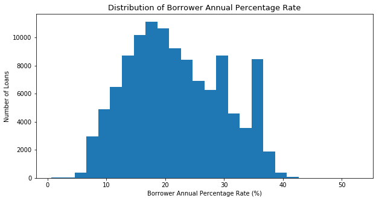

```python
# Multiple BorrowerAPR by 100 to get values in term of percentage on the full dataset
df_reduced_vars['BorrowerAPR_percent']=df_reduced_vars['BorrowerAPR'].mul(100)
# Eliminate null values of BorrowerAPR from exploration
df_APR_notnull=df_reduced_vars.loc[~df_reduced_vars['BorrowerAPR'].isnull()]
# Multiple BorrowerAPR by 100 to get values in term of percentage on the smaller subset without null values of Borrower APR
df_APR_notnull['BorrowerAPR_percent']=df_APR_notnull['BorrowerAPR'].mul(100)
# Plotting histogram for BorrowerAPR
plot_hist_charts(2,df_APR_notnull['BorrowerAPR_percent'])
x_y_t('Borrower Annual Percentage Rate (%)','Number of Loans','Distribution of Borrower Annual Percentage Rate')
plt.show();
```

## Distributions of Loan Original Amount

> - Loan original amount takes on a wide range of values, from 1k at the lowest, to 35k at the highest and exhibits a strong right-skewed pattern.
> - Under the log transformation, the distribution of original loan amount takes on a multimodal shape, with the highest frequency between 3K and 5K, then quickly trailing off until the next spikes at 10k and 15k

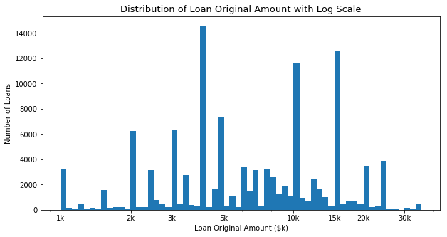

```python
# Plotting histogram for LoanOriginalAmount with log transformation
plot_log_charts(0.025,df_reduced_vars['LoanOriginalAmount'])
plt.xticks([1e3,2e3,3e3,5e3,1e4,15e3,20e3,3e4],['1k','2k','3k','5k','10k','15k','20k','30k'])
x_y_t('Loan Original Amount ($k)','Number of Loans','Distribution of Loan Original Amount with Log Scale')
plt.show();
```

## Distribution of Monthly Loan Payment

> - Monthly loan payment takes value range between 0 and slightly above two thousands, and is positive skewed.
> - Plotted on the transformation scale, the data looks normally distributed, with one peak be approximately close to 200.

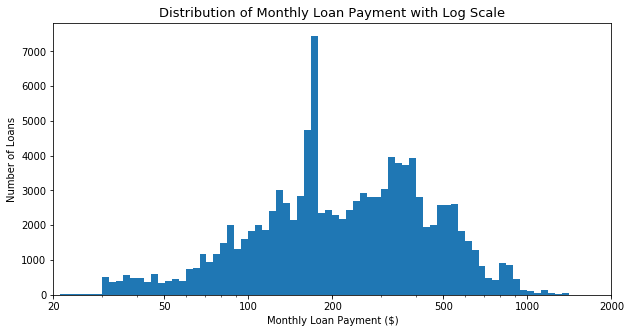

```python
# Plotting histogram for 'MonthlyLoanPayment' with log transformation
plot_log_charts(0.025,df_reduced_vars['MonthlyLoanPayment'])
plt.xticks([10,20, 50, 100, 200, 500, 1e3, 2e3], ['10', '20','50', '100', '200', '500', '1000', '2000'])
plt.xlim(20,2000)
x_y_t('Monthly Loan Payment ($)','Number of Loans','Distribution of Monthly Loan Payment with Log Scale')
plt.show();
```

## Distribution of categorical variables

> - In regards to loan status, 1/3 of loan agreements were completed sucessfully. The number of loans that fell into three different stages of defaulting on the loans (in the order of Past Due, Chargedoff, and Defaulted) were roughly half the amount of sucessful deals.
> - Prosper ratings are labeled AA, A, B, C, D, E, and HR, with AA being related to the lowest-risk customers. A large proportion of borrowers taking on loans are of Prosper rating C.
> - The income ranges of the customers is generally above average, with most of them in the 25k-50k or 50k-75k scale.

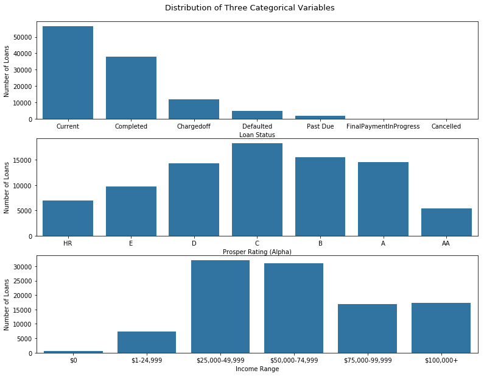

```python
def chart_order(var):
    '''
    Function to return the order of value_counts() for any column
    '''
    order=df_reduced_vars[var].value_counts().index
    return order

# let's plot the distributions of three categorical variables.
fig, ax = plt.subplots(nrows=3, figsize = [13,10])
default_color=sb.color_palette()[0]
fig.suptitle('Distribution of Three Categorical Variables',y = 0.92, x = 0.5,size=13)
ax1=sb.countplot(data = df_reduced_vars, x= 'LoanStatus_grouped', color = default_color, ax = ax[0],order=chart_order('LoanStatus_grouped'))
ax2=sb.countplot(data = df_reduced_vars, x= 'ProsperRating (Alpha)', color = default_color, ax = ax[1])
ax3=sb.countplot(data = df_reduced_vars, x= 'IncomeRange', color = default_color, ax = ax[2])
ax1.set_xlabel('Loan Status',size=10)
ax2.set_xlabel('Prosper Rating (Alpha)',size=10)
ax3.set_xlabel('Income Range',size=10)
ax1.set_ylabel('Number of Loans',size=10)
ax2.set_ylabel('Number of Loans',size=10)
ax3.set_ylabel('Number of Loans',size=10)
plt.show();
```

## Borrower APR and Loan Original Amount Distribution by Two Ordinal Variables

> - Prosper rating score appears to have the strongest relationships with the two numeric variables but in two opposite directions, negative correlation with interest rate but positive relationship with Loan original amount.
> - Similarly, the customers with the higher income ranges seem to get the cheaper borrowing rate, and also tend to be provided with bigger on loan amount.

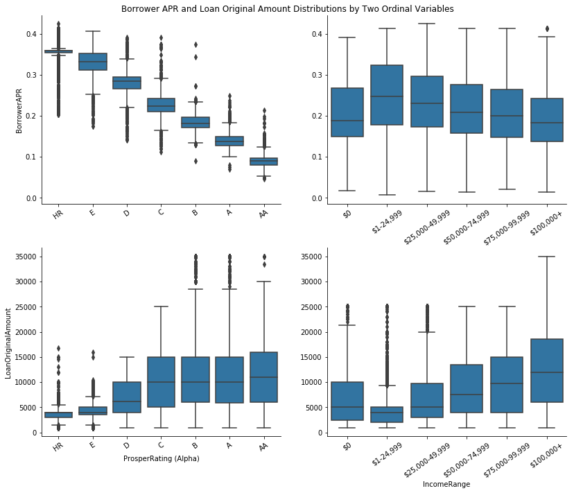

```python
def boxchart(x, y, **kwargs):
    """
    Function to create box plots with seaborn's PairGrid.
    """
    default_color = sb.color_palette()[0]
    sb.boxplot(x=x, y=y, color=default_color)

g = sb.PairGrid(data = df_reduced_vars, y_vars=['BorrowerAPR', 'LoanOriginalAmount'],
                x_vars = ['ProsperRating (Alpha)','IncomeRange'],aspect=1.5)
g.map(boxchart)
g.fig.set_size_inches(12,10)
for ax in g.axes.flat:
    ax.set_xticklabels(ax.get_xticklabels(), rotation=35)
g.fig.suptitle("Borrower APR and Loan Original Amount Distributions by Two Ordinal Variables")
plt.show();
```

## Borrower APR vs Loan Original Amount

> - Plotting Borrower APR and loan original amount on a logarithmic scale produces a negative relationship, meaning bigger quantities of loan resulting in cheaper borrowing rates for customers.
> - One of the reasonably explanatory factor is the fact that customers approved bigger amount of loan are also associated with cheaper loans due to their trustworthy credit scores or high income status. This worths further investigating in the upcoming multivariate exploration.

```python
# Compute the logarithm of Loan Original Amount to make multivariate plotting easier
def log_trans(x, inverse = False):
    """ Function to compute log and power operations """
    if not inverse:
        return np.log10(x)
    else:
        return np.power(10, x)

df_reduced_vars['log_loan_amount'] = df_reduced_vars['LoanOriginalAmount'].apply(log_trans)
```

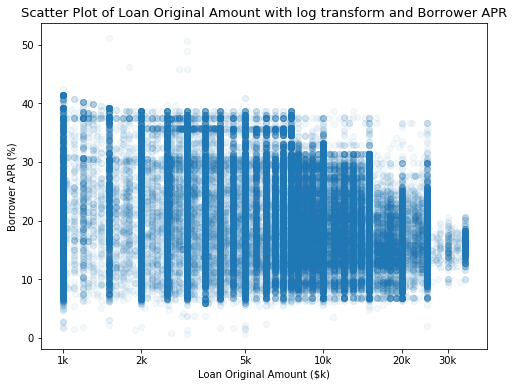

```python
# Create the scatter plot of BorrowerAPR and Loan Original Amount on the log transform with full data
plt.figure(figsize = [8, 6])
plt.scatter(data = df_reduced_vars, x = 'log_loan_amount', y = 'BorrowerAPR_percent', alpha = 1/20)
plt.xticks(log_trans(np.array([1e3, 2e3, 5e3, 1e4, 2e4,3e4])),
               ['1k', '2k', '5k', '10k', '20k','30k'])
x_y_t('Loan Original Amount ($k)','Borrower APR (%)','Scatter Plot of Loan Original Amount with log transform and Borrower APR');
```

## Borrower APR vs Loan Original Amount across Prosper Rating

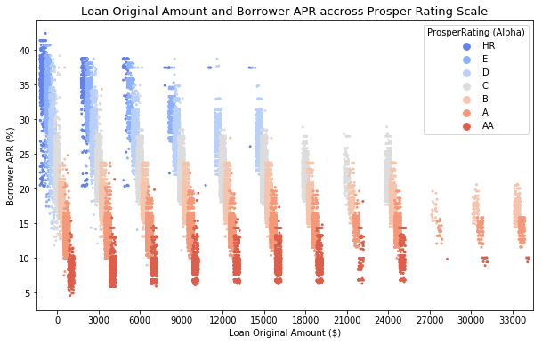

```python
# Transpose describe dataframe of Loan Original Amount to make decision on the bin of new categorical variable 'LoanAmount'
df_reduced_vars['LoanOriginalAmount'].describe().to_frame().T
# use floor division (lowest integer value) to create categorical variable
df_reduced_vars['LoanAmount']=((df_reduced_vars['LoanOriginalAmount']//3000)*3000)
df_reduced_vars['LoanAmount'].value_counts().sort_index()

# Create striplot of Loan Original Amount and Borrower APR accross Prosper Rating Scale
plt.figure(figsize = [10, 6])
ax=sb.stripplot(data=df_reduced_vars,x='LoanAmount',y = 'BorrowerAPR_percent' ,hue='ProsperRating (Alpha)',jitter=0.5,palette='coolwarm',dodge=True ,size=3)
x_y_t('Loan Original Amount ($)','Borrower APR (%)','Loan Original Amount and Borrower APR accross Prosper Rating Scale');
```

## Borrower APR vs Loan Original Amount across Monthly Loan Payment

> - The scatter plot depicts a significant postive correlation between loan original amount and monthly loan payment.
> - High proportion of borrowers seem to take loans smaller than 10k,mostly between 3K and 5K and pay less than 200 monthly.
> - There are few customers borrowing more than 30k and paying monthly more than 1k.

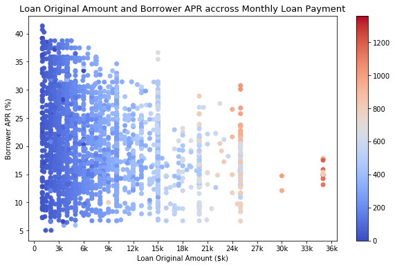

```python
# Create a random sample of 3000 loans from the full dataset to deal with overplotting issue
np.random.seed(2018)
sample_3000=np.random.choice(df_reduced_vars.shape[0],3000,replace=False)
subset_3000=df_reduced_vars.loc[sample_3000]
plt.figure(figsize = [10, 6])
plt.scatter(data = subset_3000, x = 'LoanOriginalAmount', y = 'BorrowerAPR_percent',c='MonthlyLoanPayment',cmap='coolwarm')
plt.xticks([0,3e3,6e3,9e3,12e3,15e3,18e3,21e3,24e3,27e3,30e3,33e3,36e3],
           ['0','3k', '6k', '9k','12k', '15k', '18k', '21k','24k', '27k', '30k', '33k','36k'])
plt.colorbar()
x_y_t('Loan Original Amount ($k)','Borrower APR (%)','Loan Original Amount and Borrower APR accross Monthly Loan Payment');
```

## Borrower APR and Income Range accross Loan Status

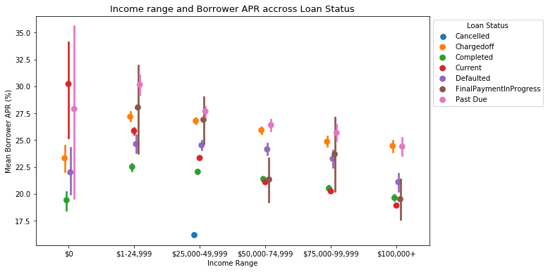

```python
# Create pointplot of Income range and Borrower APR accross Loan Status
plt.figure(figsize = [10, 6])
ax=sb.pointplot(data=df_reduced_vars,x='IncomeRange',y = 'BorrowerAPR_percent' ,hue='LoanStatus_grouped',linestyles="",dodge=True)
x_y_t('Income Range','Mean Borrower APR (%)','Income range and Borrower APR accross Loan Status')
plt.legend(bbox_to_anchor=(1,1),title='Loan Status',loc="upper left");
```

```python
!jupyter nbconvert  Part_II_slide_deck.ipynb  --to slides --post serve  --no-input --no-prompt
```